# Predictors of Red Wine Quality by Andrea Brown

### Wine Quality vs. Alcohol Content

Alcohol content actually looks pretty correlated after a lognormal transformation!

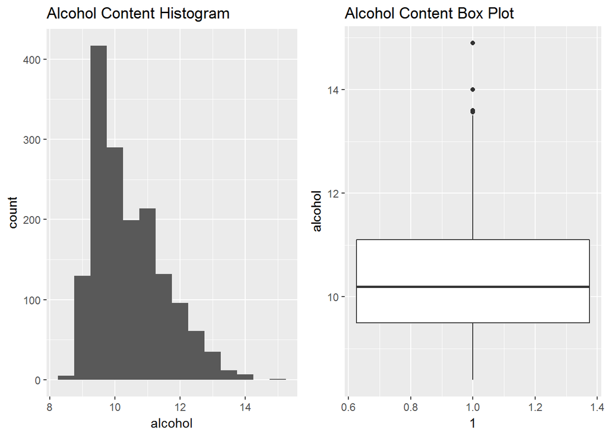

```
##
##  Pearson's product-moment correlation
##
## data:  wines$quality and log10(wines$alcohol)
## t = 21.687, df = 1597, p-value < 2.2e-16
## alternative hypothesis: true correlation is not equal to 0
## 95 percent confidence interval:
##  0.4382062 0.5139842
## sample estimates:
##       cor
## 0.4769811
```

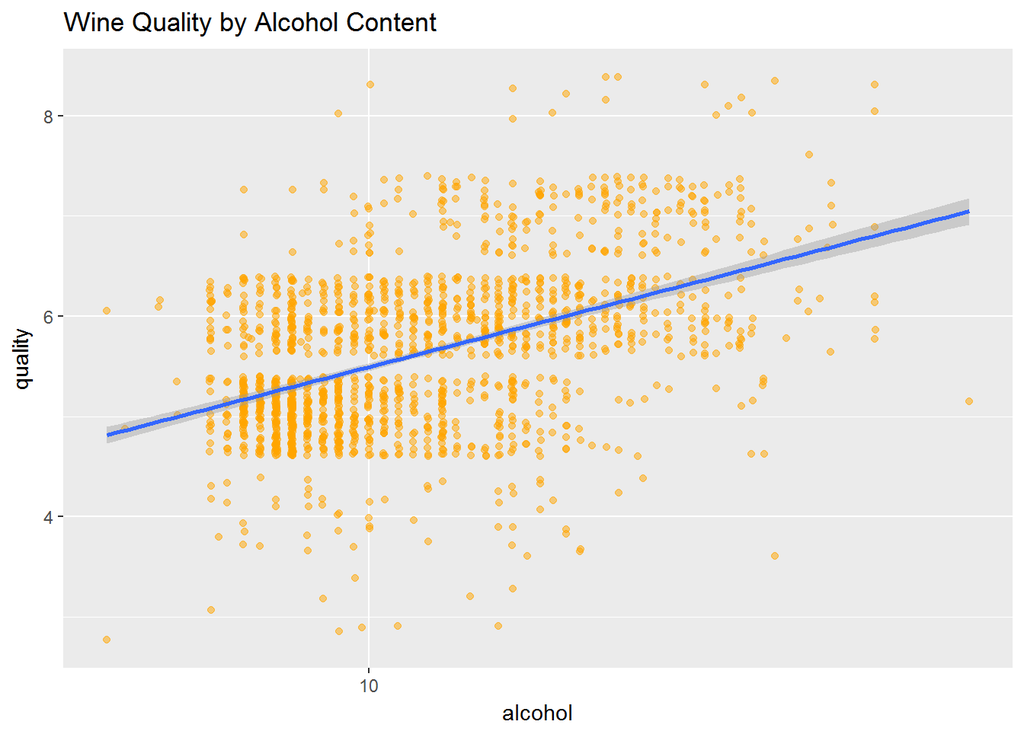

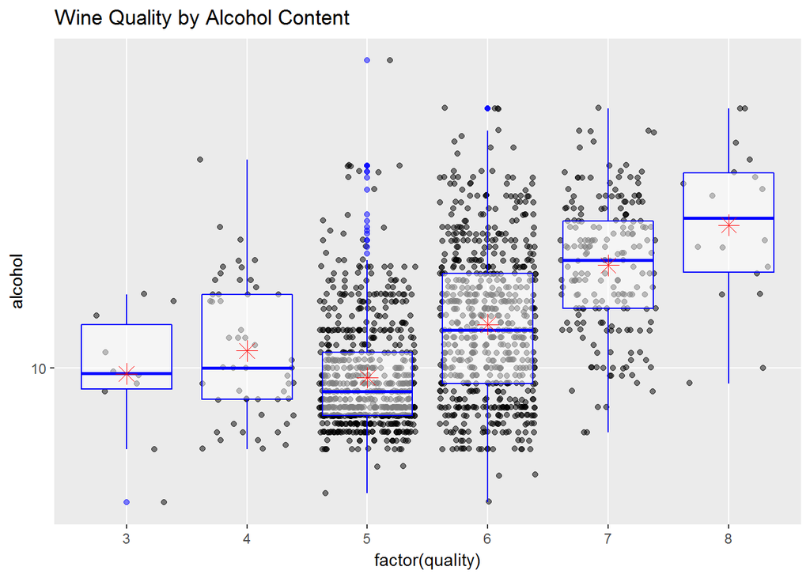

### Potential Model Parameters

Volatile acidity, sulphates, and alcohol content all look like promising candidates for the regression model. I’ll make a matrix scatter plot of these variables to make sure they are not correlated to eachother. After plotting, it looks like there may be some correlation between sulphates and volatile acidity.

```
## [1] "volatile.acidity" "sulphates"        "alcohol"
## [4] "quality"
```

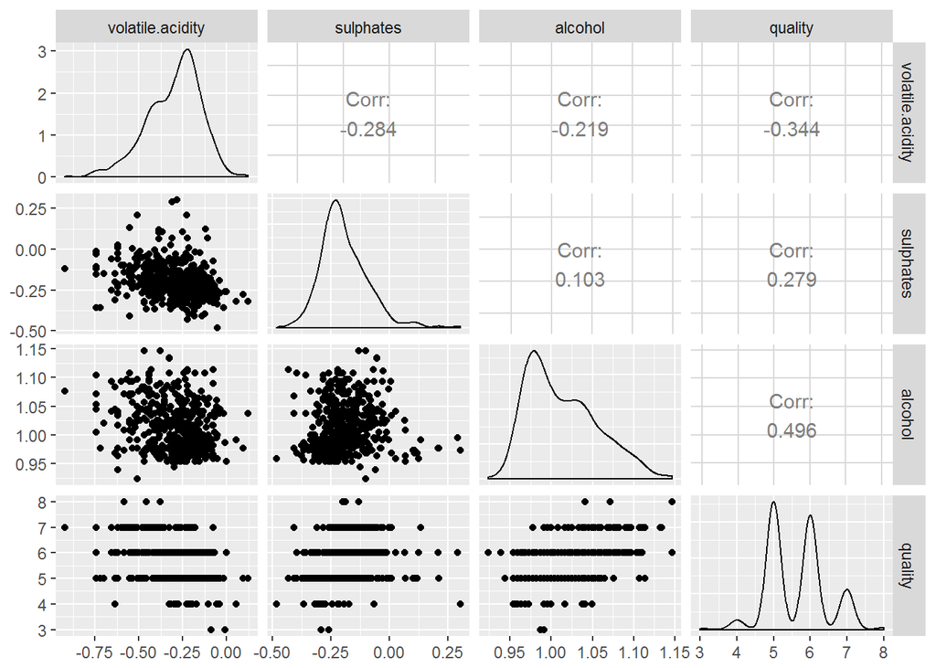

# Predictor Variables Analysis

After transforming non-linear data and looking at the correlation to the wine quality, volatile acidity, sulphates, and alcohol content all look like promising candidates for the regression model. Alcohol content had the strongest correlation to wine quality. Although I need to be aware of the potential correlation between sulphates and volatile acidity, I will cotinue investigating these variables.

# Multivariate Plots Section

### Quality vs. Alcohol Content and Volatile Acidity

I use the Color Brewer library to add volatile acidity to a scatterplot of quality vs. alcohol. There is a noticeable trend and I definitely want to test how volatile acidity works in my regression model.

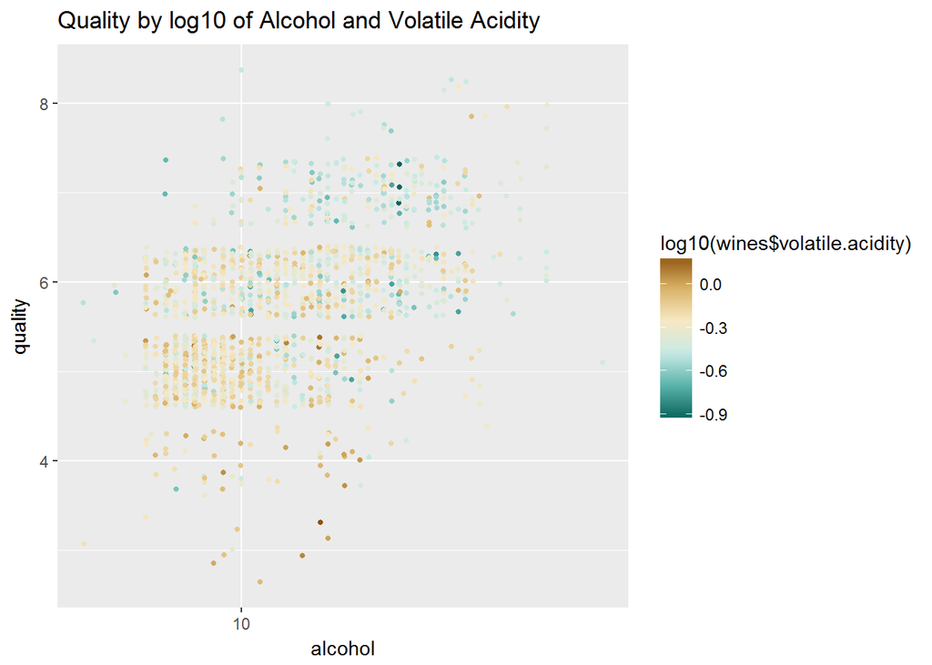

### Quality vs. Alcohol Content and Sulphates

I use the Color Brewer library to add sulphates to a scatterplot of quality vs. alcohol. Although the trend is less pronounced than using volatile acidity, I’ll still test how the sulphates variable works in my regression model.

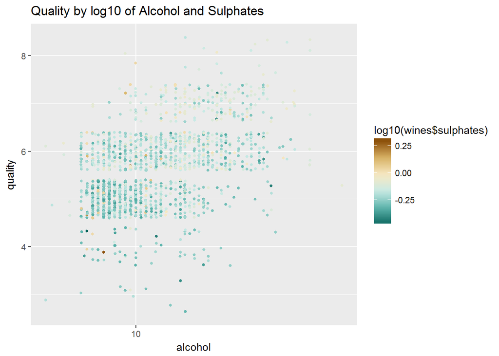

### Relationship between Residual Sugar, Alcohol Content, and Density

It was suggested to look at the relationship between residual sugar, alcohol content, and density, so I put all three variables on a plot to observe any trends. It does appear that higher density wines have higher residual sugar and lower alcohol content (i.e. sweeter wines are more dense and have less alcohol). After some reading about wine making, it seems that the sugar has a direct impact on the alcohol content of the wine, so it’s surprising that the residual sugars variable is not more correlated to the quality of the wine.

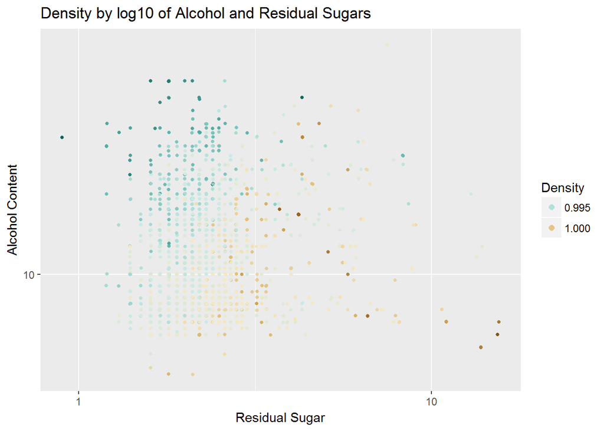

I also converted the residual sugar concentration into grams of sugar per gram of wine by dividing by the density. I compare this to the alcohol content and quality of wine, but I still don’t see a case to examine residual sugar further - alcohol content looks more correlated to wine quality.

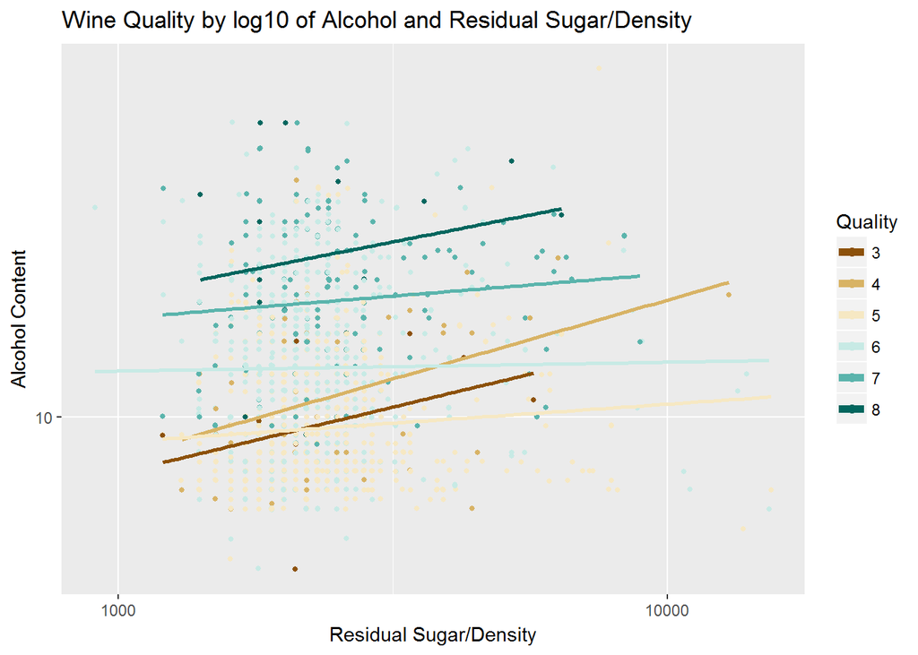

### Building the Linear Model - Quality and Alcohol

```
##
## Call:
## lm(formula = I(quality) ~ I(log(alcohol)), data = wines)
##
## Residuals:
##     Min      1Q  Median      3Q     Max
## -2.8653 -0.3942 -0.1694  0.5100  2.5846
##
## Coefficients:
##                 Estimate Std. Error t value Pr(>|t|)
## (Intercept)      -3.4740     0.4204  -8.263 2.95e-16 ***
## I(log(alcohol))   3.8948     0.1796  21.687  < 2e-16 ***
## ---
## Signif. codes:  0 '***' 0.001 '**' 0.01 '*' 0.05 '.' 0.1 ' ' 1
##
## Residual standard error: 0.71 on 1597 degrees of freedom
## Multiple R-squared:  0.2275, Adjusted R-squared:  0.227
## F-statistic: 470.3 on 1 and 1597 DF,  p-value: < 2.2e-16
```

### Building the Linear Model - Quality, Alcohol, and Volatile Acidity

```
##
## Call:
## lm(formula = I(quality) ~ I(log10(alcohol)) + I(log10(volatile.acidity)),
##     data = wines)
##
## Residuals:
##      Min       1Q   Median       3Q      Max
## -2.56407 -0.38542 -0.08262  0.46227  2.23180
##
## Coefficients:
##                            Estimate Std. Error t value Pr(>|t|)
## (Intercept)                 -2.6475     0.4015  -6.595 5.77e-11 ***
## I(log10(alcohol))            7.6871     0.4012  19.162  < 2e-16 ***
## I(log10(volatile.acidity))  -1.5650     0.1122 -13.951  < 2e-16 ***
## ---
## Signif. codes:  0 '***' 0.001 '**' 0.01 '*' 0.05 '.' 0.1 ' ' 1
##
## Residual standard error: 0.6705 on 1596 degrees of freedom
## Multiple R-squared:  0.3115, Adjusted R-squared:  0.3106
## F-statistic:   361 on 2 and 1596 DF,  p-value: < 2.2e-16
```

### Building the Linear Model - Quality, Alcohol, Volatile Acidity, and Sulphates

```
##
## Call:
## lm(formula = I(quality) ~ I(log10(alcohol)) + I(log10(volatile.acidity)) +
##     I(log10(sulphates)), data = wines)
##
## Residuals:
##      Min       1Q   Median       3Q      Max
## -2.74849 -0.37103 -0.06037  0.48191  2.11809
##
## Coefficients:
##                            Estimate Std. Error t value Pr(>|t|)
## (Intercept)                 -2.0226     0.3995  -5.063  4.6e-07 ***
## I(log10(alcohol))            7.4396     0.3935  18.906  < 2e-16 ***
## I(log10(volatile.acidity))  -1.2988     0.1141 -11.385  < 2e-16 ***
## I(log10(sulphates))          1.5139     0.1773   8.537  < 2e-16 ***
## ---
## Signif. codes:  0 '***' 0.001 '**' 0.01 '*' 0.05 '.' 0.1 ' ' 1
##
## Residual standard error: 0.6559 on 1595 degrees of freedom
## Multiple R-squared:  0.3416, Adjusted R-squared:  0.3403
## F-statistic: 275.8 on 3 and 1595 DF,  p-value: < 2.2e-16
```

### Plotting the Predicted Quality and the Actual Quality

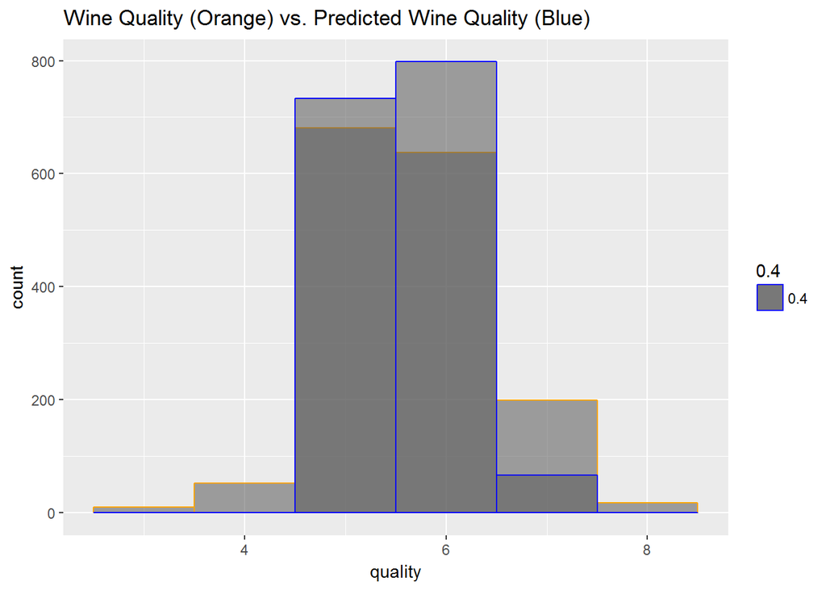

### Plotting the Error

A scatterplot of the residual error against the predicted outcome and a histogram of the standard error for each predicted outcome reveals a fairly normal set of error indicating no additional trends in the data.

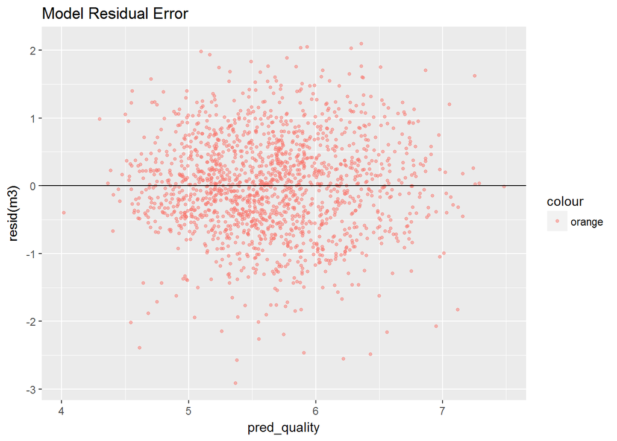

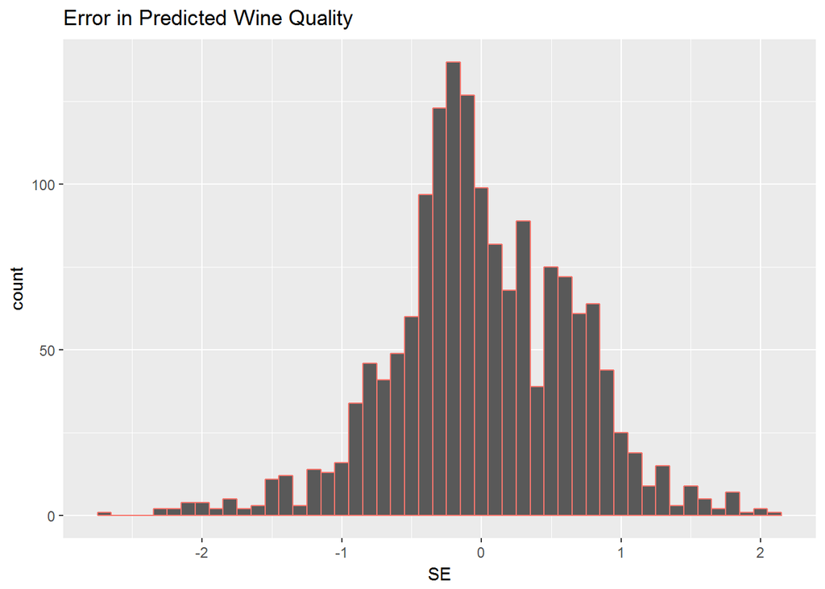

# Multivariate Analysis

# Final Plots and Summary

### Plot One

```
## [1] "volatile.acidity" "sulphates"        "alcohol"
## [4] "quality"
```

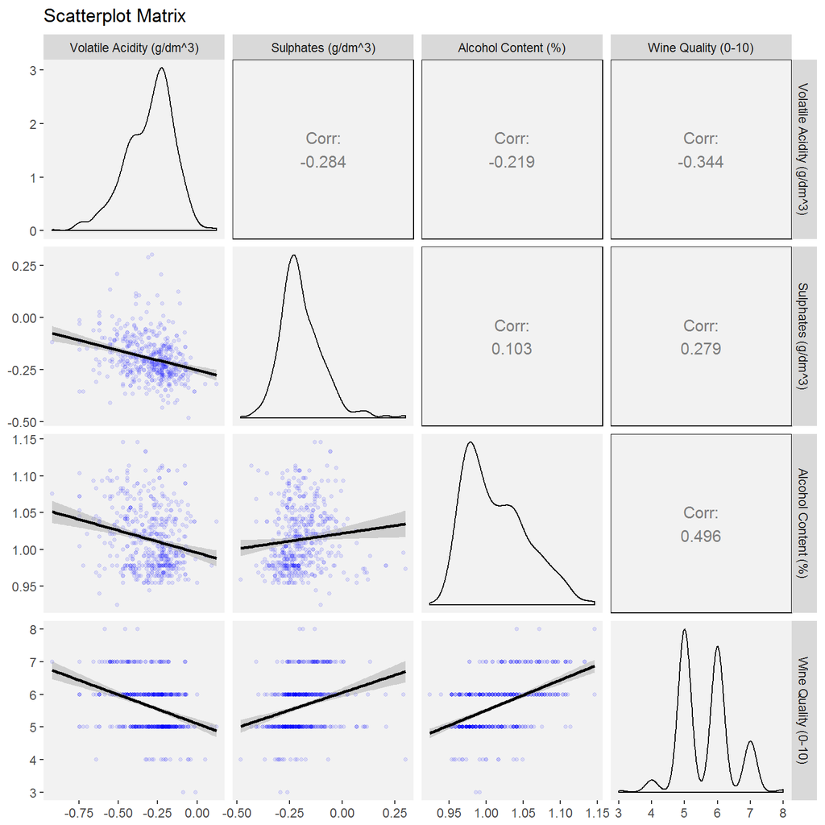

### Description One

This is a matrix of scatterplots and correlation coefficients displaying the correlations between the variables in my model. I think it is important because in one plot it demonstrates the correlations between the dependent and independent variables as well as correlations of one dependent variable to another.

### Plot Two

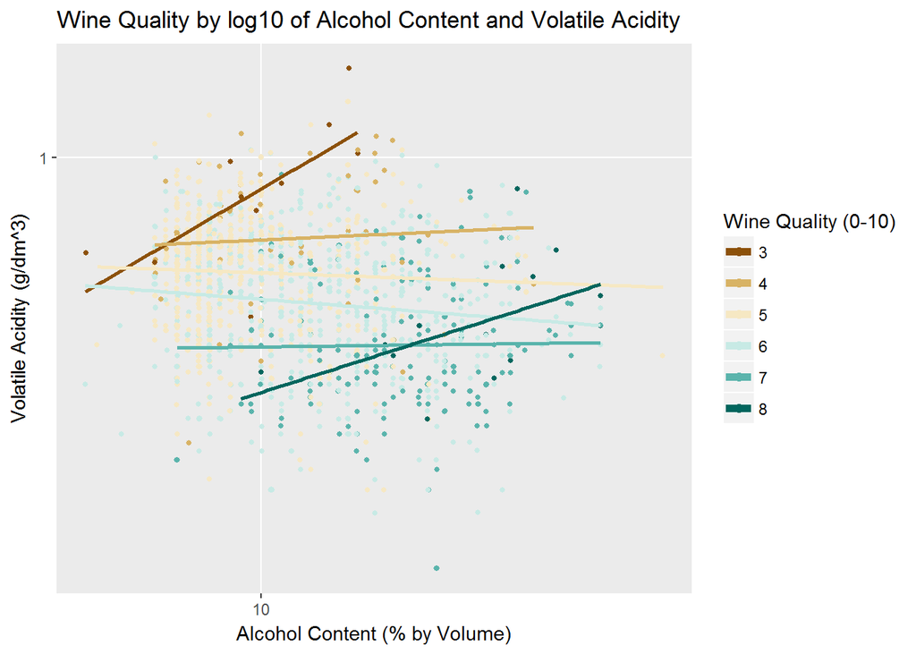

### Description Two

This is a plot of the relationship between the wine quality, alcohol, and volatile acidity. These were the most correlated looking variables, and the variables I ended up using in my linear model. It was suggested to use wine quality for the color variable and add the linear trend, which makes the plot much clearer.

### Plot Three

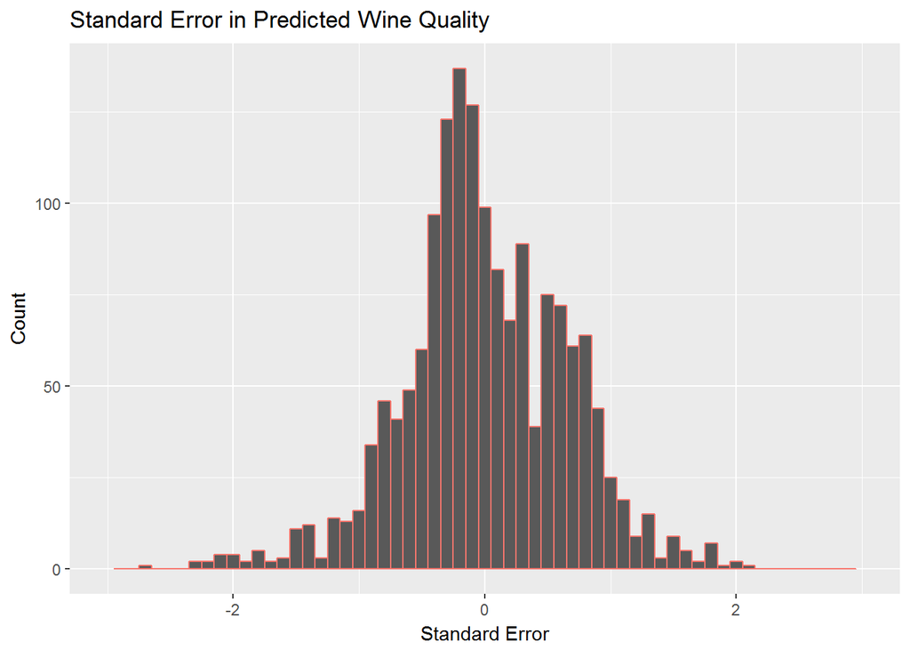

### Description Three

This is a histogram plot of the error for the predicted wine quality for the 1,599 wines. It’s a good viusalization of the accuracy of the model. Amost all of the standard error falls between -2 and 2 and it is normally distributed.

# Reflection

One thing I had trouble with during the analysis was deciding which plots to use when all my data was continuous except for the outcome variable. For example, at first I wasn’t sure how to incorporate box plots since there was no categorical data. Another thing I had trouble with was what to use as the X-axis for the standard error plot - then it was suggested to use a histogram instead of a bar plot which was a great way to show normally distributed error!

I was surprised that my model had significant results. The correlations of the chemical properties didn’t appear to be very strong in the scatterplots, so I had low expectations for the linear regression model. I think more sample groups of data would improve and validate the model.

Problems in the model include: 1. There is not much variation in the dependent variable (between 3 and 8 with the vast majority being 5, 6, or 7). 2. The model is definitely not perfect and should have a larger sample size to increase accuracy. 3. The model should be validated using a second sample group of data.